# Data Dive - GLMs (Part 2)

Amritha Prakash

2023-11-04

## ASSIGNMENT 11

### Task(s)

- Part 1: Build a linear (or generalized linear) model as you like
  - Use whatever response variable and explanatory variables you prefer
- Part 2: Use the tools from previous weeks to diagnose the model.
  - Highlight any issues with the model.
- Part 3: Interpret at least one of the coefficients

### **Read the Data**

```r
Superstore_data=read.csv("SampleSuperstore_final.csv")
head(Superstore_data)
```

```
##        Ship.Mode   Segment       Country            City      State Postal.Code
## 1   Second Class  Consumer United States       Henderson   Kentucky       42420
## 2   Second Class  Consumer United States       Henderson   Kentucky       42420
## 3   Second Class Corporate United States     Los Angeles California       90036
## 4 Standard Class  Consumer United States Fort Lauderdale    Florida       33311
## 5 Standard Class  Consumer United States Fort Lauderdale    Florida       33311
## 6 Standard Class  Consumer United States     Los Angeles California       90032
##   Region        Category Sub.Category    Sales Quantity Discount    Profit
## 1  South       Furniture    Bookcases 261.9600        2     0.00   41.9136
## 2  South       Furniture       Chairs 731.9400        3     0.00  219.5820
## 3   West Office Supplies       Labels  14.6200        2     0.00    6.8714
## 4  South       Furniture       Tables 957.5775        5     0.45 -383.0310
## 5  South Office Supplies      Storage  22.3680        2     0.20    2.5164
## 6   West       Furniture  Furnishings  48.8600        7     0.00   14.1694
```

**1. Part 1 -** Build a linear (or generalized linear) model as you like

- Since the data set is about a Superstore, will try to figure out the profit for certain region say “West”
- Let the **Response variable be Profit** and **Explanatory variable be Sales.**
- Unable to take multiple explanatory variables as they would end up being binary if converted the categorical columns. Not much can be figured out in a linear model for same.

```r
Sup_data_filtered <- Superstore_data |>
  filter(Profit >0, Region == 'West', Segment== 'Home Office')

sup_grouped <-
  Superstore_data |>
  filter(Profit >0, Region == 'West', Segment== 'Home Office') |>
  group_by(Region) |>
  summarise(mean_profit = mean(Profit))

sup_grouped
```

```
## # A tibble: 1 × 2
##   Region mean_profit
##   <chr>        <dbl>
## 1 West          47.1
```

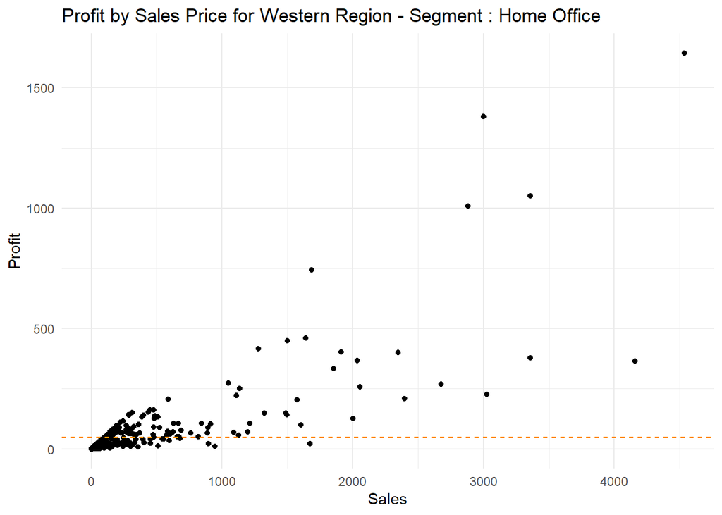

```r
Sup_data_filtered |>
  ggplot() +
  geom_point(mapping = aes( x= Sales, y = Profit)) +
  geom_hline(data = sup_grouped,
             mapping = aes(yintercept = mean_profit),
             color = 'darkorange', linetype = 'dashed') +
  labs(title = "Profit by Sales Price for Western Region - Segment : Home Office",
       x = "Sales", y = "Profit") +
  theme_minimal()
```

```r
model <- lm( Profit ~ Sales, data = Sup_data_filtered)

model$coefficients
```

```
## (Intercept)       Sales
##   0.1877567   0.1970041
```

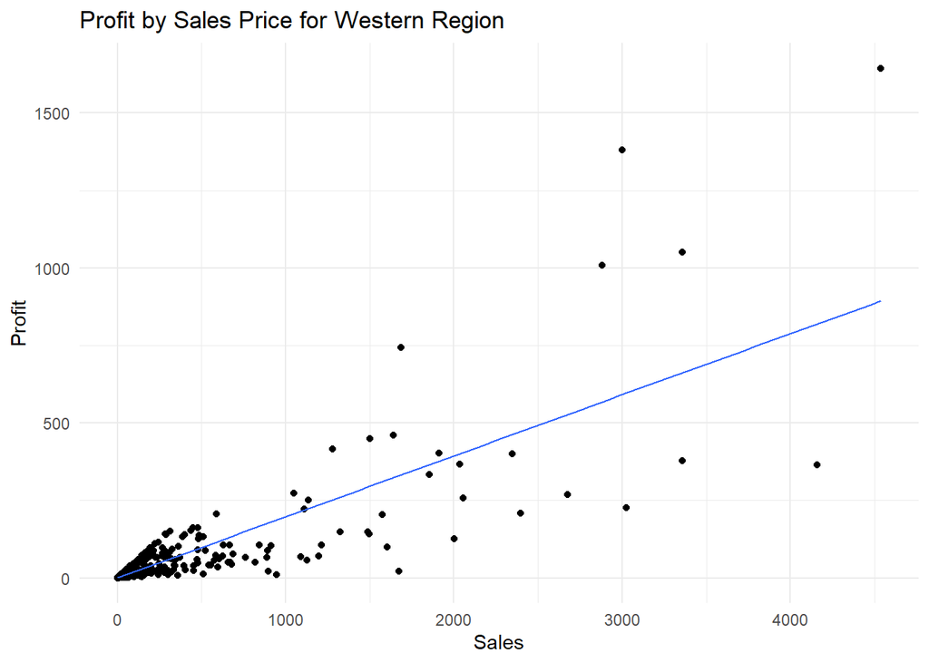

```r
Sup_data_filtered |>
  ggplot(mapping = aes( x= Sales, y = Profit)) +
  geom_point() +
  geom_smooth(method = 'lm', se = FALSE, linewidth = 0.5) +
  labs(title = "Profit by Sales Price for Western Region",
       x = "Sales", y = "Profit") +
  theme_minimal()
```

Since the data is like a cone in shape will try to make use of transformation to Response variable i.e. Profit.

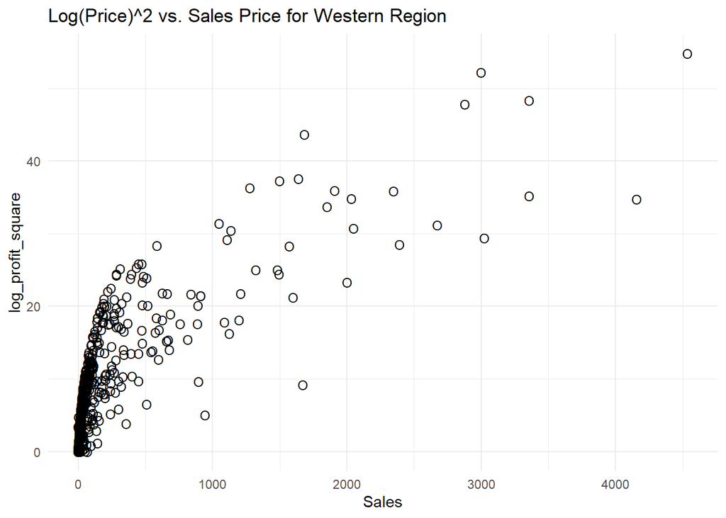

```r
Sup_data_filtered <- Sup_data_filtered |>
  mutate(log_profit_square = (log(Profit))**2)

Sup_data_filtered |>
  ggplot(mapping = aes(x = Sales, y = log_profit_square)) +
  geom_point(shape = 'O', size = 3) +
  labs(title = "Log(Price)^2 vs. Sales Price for Western Region") +
  theme_minimal()
```

```r
model <- glm( log_profit_square ~ Sales, data = Sup_data_filtered)

model$coefficients
```

```
## (Intercept)       Sales
##   6.2522707   0.0127788
```

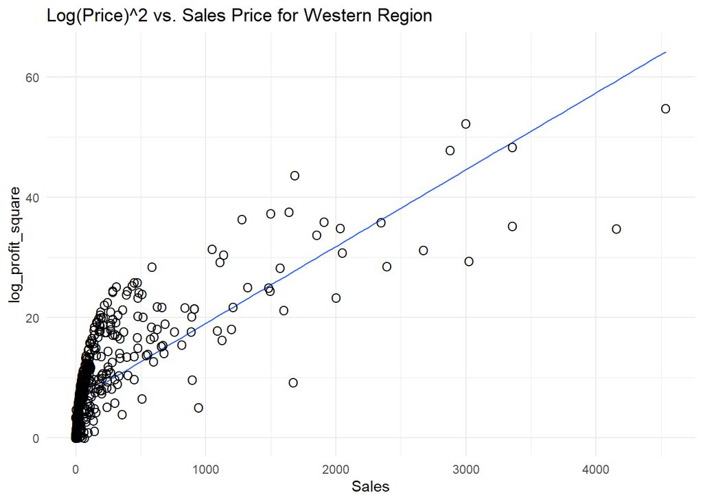

```r
Sup_data_filtered |>
  ggplot(mapping = aes(x = Sales, y = log_profit_square)) +
  geom_smooth(method = 'glm', se = FALSE, linewidth = 0.5) +
  geom_point(shape = 'O', size = 3) +
  labs(title = "Log(Price)^2 vs. Sales Price for Western Region") +
  theme_minimal()
```

**Part 2:** Use the tools from previous weeks to diagnose the model.Highlight any issues with the model.

- Can see that the plots are spread almost nearly. But profit for sales with minimum value aren’t much spread out and overlap still (after transformation too).
- Not quite sure if any more better ways exist to read those such that they are
- But overall can see that there is a linear relation between sales and profit for the western region where the product segment is Home Office.

```r
# Assess model fit
summary(model)
```

```
##
## Call:
## glm(formula = log_profit_square ~ Sales, data = Sup_data_filtered)
##
## Coefficients:
##              Estimate Std. Error t value Pr(>|t|)
## (Intercept) 6.2522707  0.2659445   23.51   <2e-16 ***
## Sales       0.0127788  0.0004497   28.42   <2e-16 ***
## ---
## Signif. codes:  0 '***' 0.001 '**' 0.01 '*' 0.05 '.' 0.1 ' ' 1
##
## (Dispersion parameter for gaussian family taken to be 30.34772)
##
##     Null deviance: 39984  on 511  degrees of freedom
## Residual deviance: 15477  on 510  degrees of freedom
## AIC: 3204.3
##
## Number of Fisher Scoring iterations: 2
```

```r
coef(model)
```

```
## (Intercept)       Sales
##   6.2522707   0.0127788
```